# Titanic - Survival Rate

Mughundhan Chandrasekar

4/15/2017

### **INTRODUCTION**

The sinking of the RMS Titanic is one of the most infamous shipwrecks in history. On April 15, 1912, during her maiden voyage, the Titanic sank after colliding with an iceberg, killing 1502 out of 2224 passengers and crew. This sensational tragedy shocked the international community and led to better safety regulations for ships.

One of the reasons that the shipwreck led to such loss of life was that there were not enough lifeboats for the passengers and crew. Although there was some element of luck involved in surviving the sinking, some groups of people were more likely to survive than others, such as women, children, and the upper-class.

This mini-project involves the analysis of what sorts of people were likely to survive.

### **1.Creating an Environment**

This stage involves the following: - Setting up a working directory to access Titanic dataset (data classified: 1. Train and 2. Test) - Loading the train dataset and other required libraries to this envrionment

```r
rm(list=ls())
library(NLP)
library(tm)
library(R.utils)
library(stringi)
library(data.table)
library(ggplot2)
library(SnowballC)
library(caret)        # Confusion Matrix
library(pscl)         # For R^2
library(ROCR)         # for ROC and AUC
setwd("/Users/Mughundhan/KAGGLE/Titanic")
train <- read.csv("train.csv")
#Columns available in the original Data-set
colnames(train)
```

```
##  [1] "PassengerId" "Survived"    "Pclass"      "Name"        "Sex"
##  [6] "Age"         "SibSp"       "Parch"       "Ticket"      "Fare"
## [11] "Cabin"       "Embarked"
```

### **2.Cleaning the data**

- Remove unnecessary columns (that are not useful in the modeling): Columns such as Ticket, Cabin and Embarked are of no great use. So, these columns shall be removed
- Handle missing values
- Columns available after removing the unnecessary columns.

```r
colnames(train)
```

```
## [1] "PassengerId" "Survived"    "Pclass"      "Name"        "Sex"
## [6] "Age"         "SibSp"       "Parch"       "Fare"
```

**2.1.Name Cannonicalization** into title-groups:

The names of the passengers are given as follows:

```
## [1] "Braund, Mr. Owen Harris"
## [2] "Cumings, Mrs. John Bradley (Florence Briggs Thayer)"
## [3] "Heikkinen, Miss. Laina"
## [4] "Futrelle, Mrs. Jacques Heath (Lily May Peel)"
## [5] "Allen, Mr. William Henry"
## [6] "Moran, Mr. James"
```

After performing Cannonicalization, the above names are replaced as follows:

```
## [1] "Mr"   "Mrs"  "Miss" "Mrs"  "Mr"   "Mr"
```

#### **2.2.Handling Missing Values**

##### **2.2.1.Compute Average** for each title-group -

- Age column shall not be removed: Substitute the mean age values of each section of people (instead of taking an universal average - makes our prediction more efficient) in place of the missing values.
- For instance, if a person’s age field is missing, and the person’s name is “Mr.”, then the mean of the age of all passengers whose name is “Mr.” is replaced in place of missing field. Likewise, it is done for Mrs, Miss, Master, Dr and Rev.

**Operations performed on the dataset with missing values.**

```r
#Number of NA values after cleaning the data
sum(is.na(train$Age))
```

```
## [1] 177
```

```r
#Maximum Age
max(train$Age)
```

```
## [1] NA
```

```r
#Minimum Age
min(train$Age)
```

```
## [1] NA
```

**Operations performed on the dataset, after handling the missing values.**

```r
#Number of NA values after cleaning the data
sum(is.na(train$Age))
```

```
## [1] 0
```

```r
#Maximum Age
max(train$Age)
```

```
## [1] 80
```

```r
#Minimum Age
min(train$Age)
```

```
## [1] 0.42
```

##### **2.2.2.Alternative Way** - Not evaluated

**2.3.Creating New Varaibles and Discretization**

- New Variable: **Family**: 1+ SibSp + Parch
- New Variable: **Fare2**: Discrete Fare Column (four bins)

```
##   PassengerId Survived Pclass Name    Sex   Age SibSp Parch    Fare
## 1           1        0      3   Mr   male 22.00     1     0  7.2500
## 2           2        1      1  Mrs female 38.00     1     0 71.2833
## 3           3        1      3 Miss female 26.00     0     0  7.9250
## 4           4        1      1  Mrs female 35.00     1     0 53.1000
## 5           5        0      3   Mr   male 35.00     0     0  8.0500
## 6           6        0      3   Mr   male 32.36     0     0  8.4583
##   FamilySize Fare2 Child
## 1          2  <$10     0
## 2          2  $30+     0
## 3          1  <$10     0
## 4          2  $30+     0
## 5          1  <$10     0
## 6          1  <$10     0
```

### **3.Data Exploration**

### **3.1.Female Vs Male : Survived and Deceased Comparison**

- Survival Percent for female, male is given as follows

```r
counts <- table(train$Survived, train$Sex)
#confusion Matrix
counts
```

```
##
##     female male
##   0     81  468
##   1    233  109
```

```r
female <- nrow(train[train$Sex=='female',])
male <- nrow(train[train$Sex=='male',])
slice <- c(female, male)
divi <- c("Female", "Male")

survival_percent <- c(counts[2]/(counts[1]+counts[2]), counts[4]/(counts[3]+counts[4]))
# Survival Percent for Female,   Male
survival_percent
```

```
## [1] 0.7420382 0.1889081
```

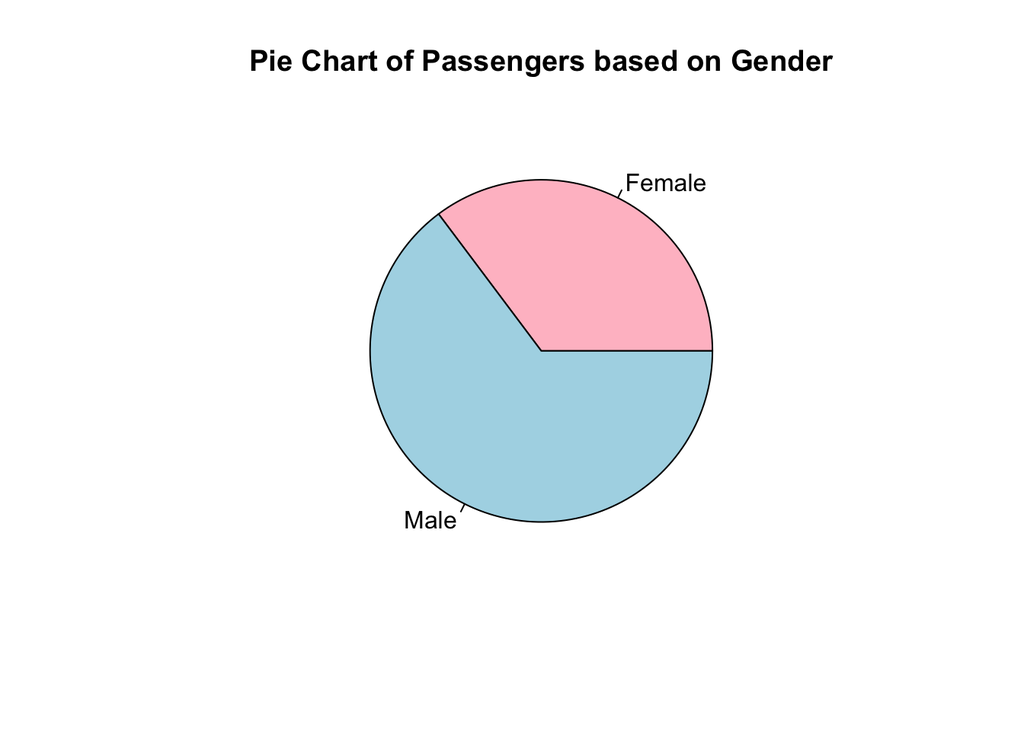

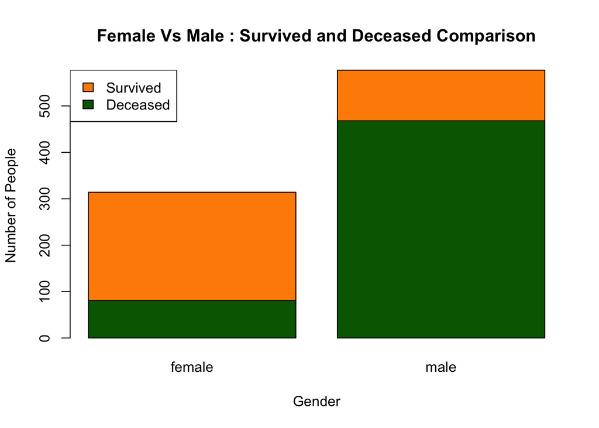

#### **Inference**

- Among the passengers in Titanic - 65% are Males and 35% are Females.
- But the analysis indicates that Females (74%) have a better survival rate than Males (18%).

### **3.2.Survived and Deceased Comparison based on the Ticket Fare**

- Survival percent for ticket fare ($10-$20, $20-$30, $30.00+, <$10.00) are given below:

```r
fcounts <- table(train$Survived, train$Fare2)
#confusion Matrix
fcounts
```

```
##
##     $10-$20 $20-$30 $30+ <$10
##   0     103      78   99  269
##   1      76      58  141   67
```

```r
fare_survival_percent <- c(fcounts[2]/(fcounts[1]+fcounts[2]), fcounts[4]/(fcounts[3]+fcounts[4]), fcounts[6]/(fcounts[5]+fcounts[6]), fcounts[8]/(fcounts[7]+fcounts[8]))
fare_survival_percent
```

```
## [1] 0.4245810 0.4264706 0.5875000 0.1994048
```

```r
# $10-$20,   $20-$30,   $30.00+,   <$10.00
```

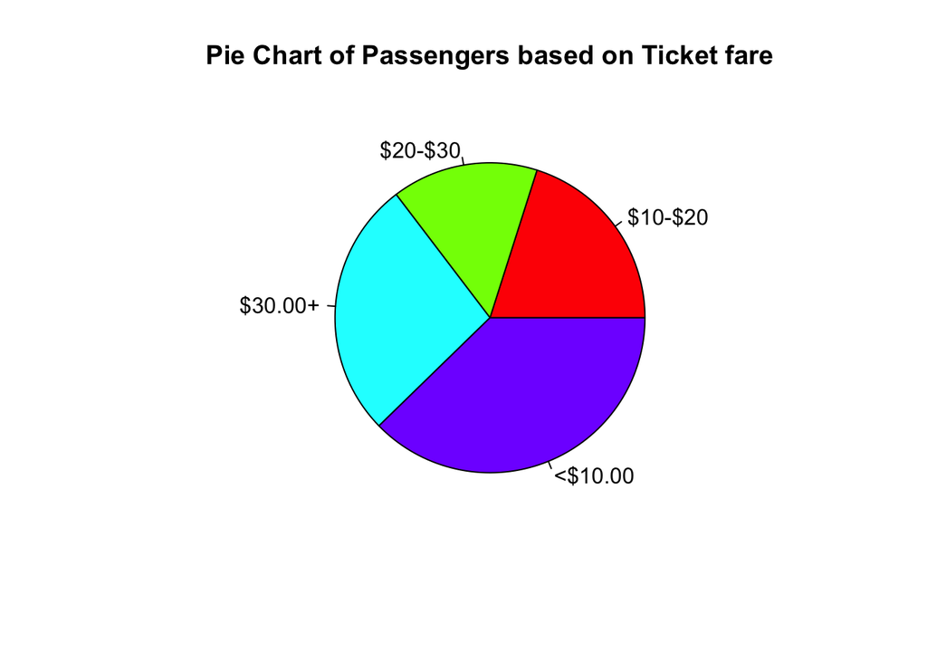

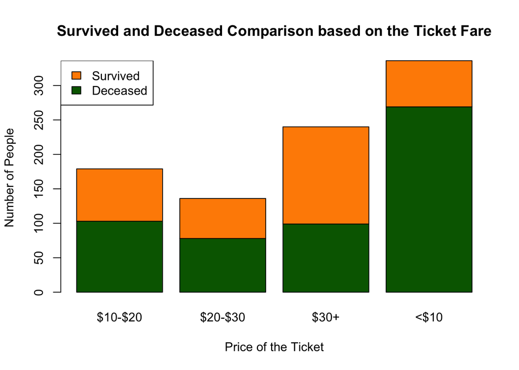

### **3.3.Survived and Deceased Comparison based on the Class**

- Survival Percent for different classes (Class1, Class2, Class3) are as follows

```r
Ccounts <- table(train$Survived, train$Pclass)
#confusion Matrix
Ccounts
```

```
##
##       1   2   3
##   0  80  97 372
##   1 136  87 119
```

```r
Class_survival_percent <- c(Ccounts[2]/(Ccounts[1]+Ccounts[2]), Ccounts[4]/(Ccounts[3]+Ccounts[4]), Ccounts[6]/(Ccounts[5]+Ccounts[6]))
Class_survival_percent
```

```
## [1] 0.6296296 0.4728261 0.2423625
```

```r
# Class(1), Class(2), Class(3)
```

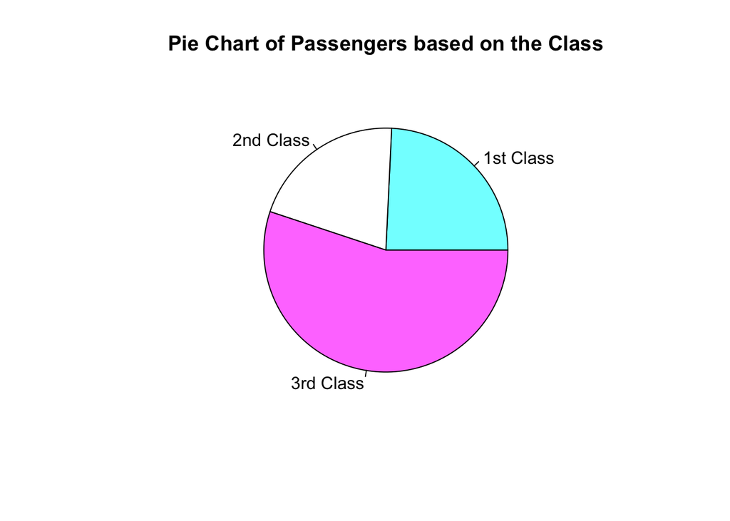

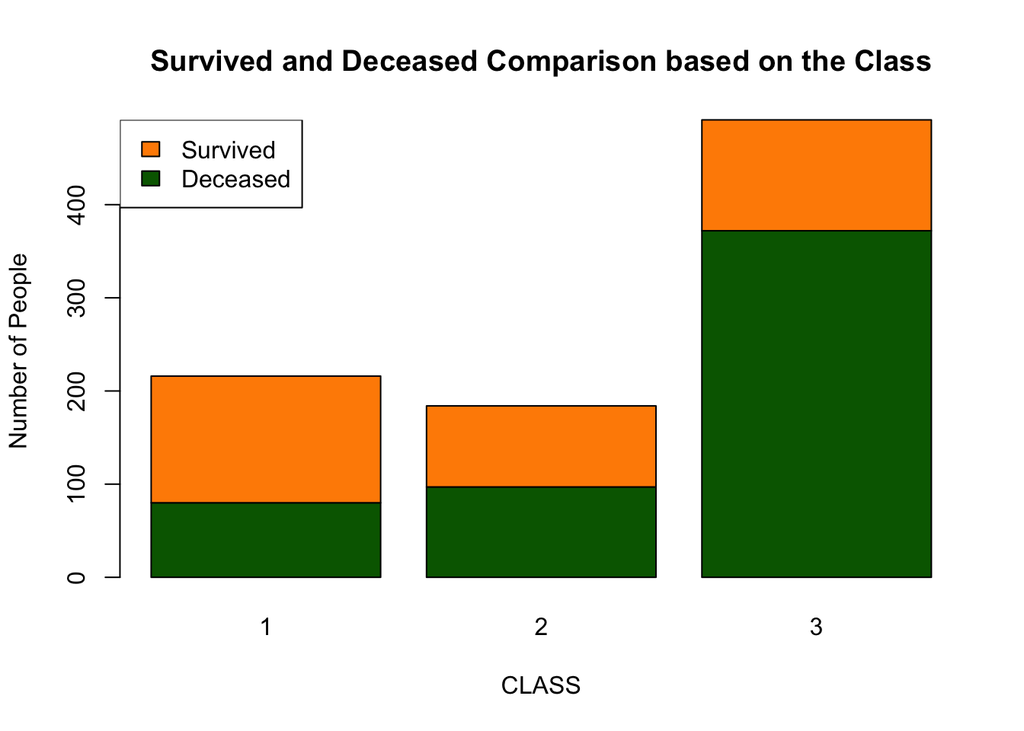

#### **Inference**

- Majority of the passengers travelled in 3rd Class.
- The analysis indicates that the passengers travelling in higher classes are more likely to survive.

### **3.4.Children Vs Others : Survived and Deceased Comparison**

- Survival Rate for children and adults are given below :

```r
CHcounts <- table(train$Survived, train$Child)
#confusion Matrix
CHcounts
```

```
##
##       0   1
##   0 495  54
##   1 279  63
```

```r
CH_survival_percent <- c(CHcounts[2]/(CHcounts[1]+CHcounts[2]), CHcounts[4]/(CHcounts[3]+CHcounts[4]))
CH_survival_percent
```

```
## [1] 0.3604651 0.5384615
```

```r
# Others,   Children
```

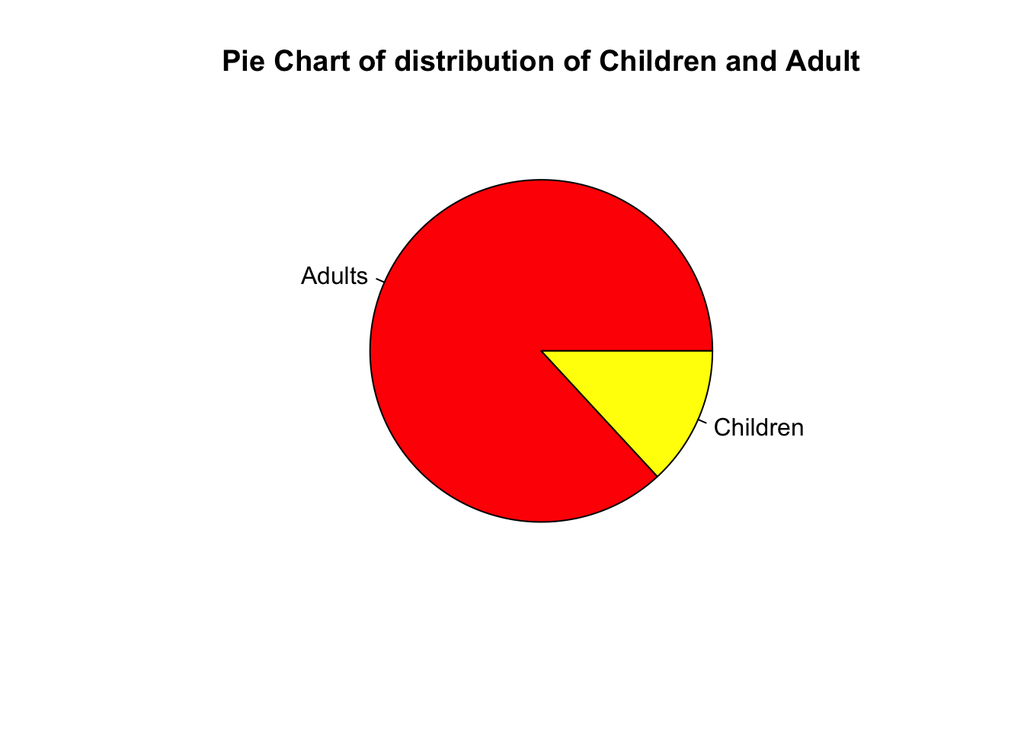

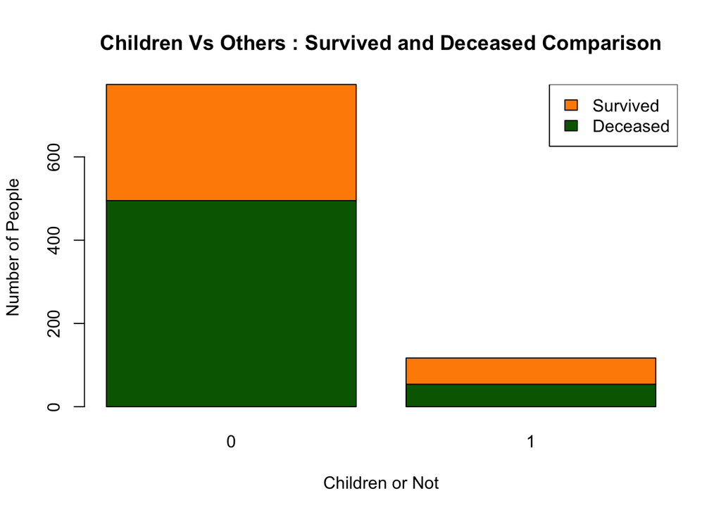

#### **Inference**

- Children consitute the microscopic minority category among the passengers on Titanic.
- From the analysis, it is very clear that children were given higher priority (age < 18 years). Thus, the survival rate for children is higher when compared with people having age >= 18 years.

### **4.Classification and Analysis**

- **Proportional Table:** Gives an idea about the number of people survived based on Gender (Actual Vs Predicted)
- **Aggregate Function:** Simply determines the combination of attributes which makes the survival rate better (given in descending order)

```
##
##                   0          1
##   female 0.09090909 0.26150393
##   male   0.52525253 0.12233446
```

```
##   Child    Sex Survived
## 1     0 female      195
## 2     1 female       38
## 3     0   male       84
## 4     1   male       25
```

```
##   Child    Sex Survived
## 1     0 female      259
## 2     1 female       55
## 3     0   male      515
## 4     1   male       62
```

### **4.1.Survival Rate based on combination of factors**

NOTE: 1.00 stands for 100% survival rate.

#### Survival Rate based on **Gender, Class of Travel, Price of Ticket, Age of Passenger**.

```
##      Fare2 Child    Sex Pclass Survived
## 7     $30+     1   male      1        1
## 10    $30+     0 female      2        1
## 11 $10-$20     1 female      2        1
## 12 $20-$30     1 female      2        1
## 13    $30+     1 female      2        1
## 20    $30+     1   male      2        1
```

#### Survival Rate based on **Gender, Class of Travel, Price of Ticket**.

```
##      Fare2    Sex Pclass  Survived
## 8     $30+ female      2 1.0000000
## 2     $30+ female      1 0.9772727
## 6  $10-$20 female      2 0.9142857
## 7  $20-$30 female      2 0.9000000
## 1  $20-$30 female      1 0.8333333
## 16    <$10 female      3 0.5937500
```

#### Survival Rate based on **Gender, Class of Travel**.

```
##      Sex Pclass  Survived
## 1 female      1 0.9680851
## 3 female      2 0.9210526
## 5 female      3 0.5000000
## 2   male      1 0.3688525
## 4   male      2 0.1574074
## 6   male      3 0.1354467
```

#### Survival Rate based on **Class of Travel, Price of Ticket, Age of Passenger**.

```
##      Fare2 Child Pclass  Survived
## 11    $30+     1      2 1.0000000
## 4     $30+     1      1 0.9166667
## 10 $20-$30     1      2 0.8888889
## 9  $10-$20     1      2 0.8571429
## 16 $10-$20     1      3 0.7500000
## 2     $30+     0      1 0.6666667
```

#### Survival Rate based on **Gender, Class of Travel, Age of Passenger**.

```
##   Child    Sex Pclass  Survived
## 4     1   male      1 1.0000000
## 6     1 female      2 1.0000000
## 1     0 female      1 0.9767442
## 5     0 female      2 0.9062500
## 2     1 female      1 0.8750000
## 8     1   male      2 0.8181818
```

#### Survival Rate based on **Gender, Age of Passenger**.

```
##   Child    Sex  Survived
## 1     0 female 0.7528958
## 2     1 female 0.6909091
## 4     1   male 0.4032258
## 3     0   male 0.1631068
```

#### Survival Rate based on **Class of Travel, Age of Passenger**.

```
##   Child Pclass  Survived
## 2     1      1 0.9166667
## 4     1      2 0.9130435
## 1     0      1 0.6127451
## 3     0      2 0.4099379
## 6     1      3 0.3780488
## 5     0      3 0.2151589
```

#### Survival Rate based on **Price of Ticket, Age of Passenger**.

```
##     Fare2 Child  Survived
## 5 $10-$20     1 0.7741935
## 3    $30+     0 0.6050000
## 7    $30+     1 0.5000000
## 2 $20-$30     0 0.4272727
## 6 $20-$30     1 0.4230769
## 8    <$10     1 0.4000000
```

### **5.Classifier Performance - Logistic Regression**

```r
# Model fitting
model <- glm(Survived ~.,family=binomial(link='logit'),data=train)

# Analysis of deviance
anova(model,test="Chisq")
```

```
## Analysis of Deviance Table
##
## Model: binomial, link: logit
##
## Response: Survived
##
## Terms added sequentially (first to last)
##
##
##             Df Deviance Resid. Df Resid. Dev  Pr(>Chi)
## NULL                          890    1186.66
## PassengerId  1    0.022       889    1186.63  0.881201
## Pclass       1  102.523       888    1084.11 < 2.2e-16 ***
## Name        18  313.614       870     770.50 < 2.2e-16 ***
## Sex          1    6.938       869     763.56  0.008438 **
## Age          1    6.010       868     757.55  0.014226 *
## SibSp        1   36.335       867     721.21 1.661e-09 ***
## Parch        1    6.021       866     715.19  0.014140 *
## Fare         1    2.742       865     712.45  0.097761 .
## FamilySize   0    0.000       865     712.45
## Fare2        3    2.300       862     710.15  0.512454
## Child        1    0.644       861     709.51  0.422412
## ---
## Signif. codes:  0 '***' 0.001 '**' 0.01 '*' 0.05 '.' 0.1 ' ' 1
```

```r
# McFadden R^2
pR2(model)
```

```
##          llh      llhNull           G2     McFadden         r2ML
## -354.7533940 -593.3275684  477.1483488    0.4020952    0.4146352
##         r2CU
##    0.5633594
```

```r
#-------------------------------------------------------------------------------------------------#

# MEASURING THE PREDICTIVE ABILITY OF THE MODEL

# If prob > 0.5 then 1, else 0. Threshold can be set for better results
fitted.results <- predict(model,newdata=train,type='response') #use test
fitted.results <- ifelse(fitted.results > 0.5,1,0)

misClasificError <- mean(fitted.results != train$Survived)
print(paste('Accuracy',1-misClasificError))
```

```
## [1] "Accuracy 0.829405162738496"
```

```r
# Confusion matrix

confusionMatrix(data=fitted.results, reference=train$Survived) #use test
```

```
## Confusion Matrix and Statistics
##
##           Reference
## Prediction   0   1
##          0 483  86
##          1  66 256
##
##                Accuracy : 0.8294
##                  95% CI : (0.8031, 0.8535)
##     No Information Rate : 0.6162
##     P-Value [Acc > NIR] : <2e-16
##
##                   Kappa : 0.6353
##  Mcnemar's Test P-Value : 0.1233
##
##             Sensitivity : 0.8798
##             Specificity : 0.7485
##          Pos Pred Value : 0.8489
##          Neg Pred Value : 0.7950
##              Prevalence : 0.6162
##          Detection Rate : 0.5421
##    Detection Prevalence : 0.6386
##       Balanced Accuracy : 0.8142
##
##        'Positive' Class : 0
##
```

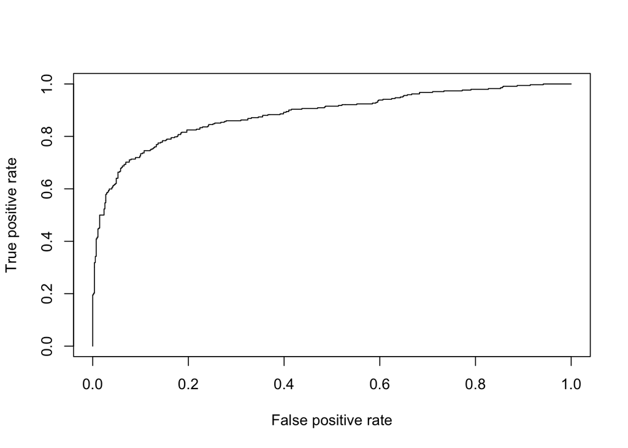

```r
# ROC and AUC
p <- predict(model, newdata=train, type="response") #use test
pr <- prediction(p, train$Survived) #use test
# TPR = sensitivity, FPR=specificity
prf <- performance(pr, measure = "tpr", x.measure = "fpr")
plot(prf)
```

```r
auc <- performance(pr, measure = "auc")
auc <- auc@y.values[[1]]
auc
```

```
## [1] 0.8837972
```

**Alternative Way:** Not evaluated

```r
perf = function(pred, act) {
  # Confusion Matrix
  xtab = table(pred, act);

  # Retrieve TP, FP, TN, FN

  TP = xtab[1,1]
  if(nrow(xtab)==2) {
    TN = xtab[2,2]
  }
  else {
    TN = 0
  }
  if(nrow(xtab)==2) {
    FP = xtab[1,2]
  }
  else {
    FP = 0
  }
  FN = xtab[2,1]


# Compute Accuracy, Precision, Recall, F-Measure

r = matrix(NA, nrow=1, ncol=4)
colnames(r) = c('Accuracy', 'Precision', 'Recall', 'F-Measure')
r[1,1] = (TP+TN)/(TP+TN+FP+FN)
r[1,2] = TP/(TP+FP)
r[1,3] = TP/(TP+FN)
r[1,4] = r[1,2]*r[1,3]
}

pred = rep(0, nrow(train)) #use test
#perf(pred, train$Survived) #use test
#-------------------------------------------------------------------------------------------------#

# Generalized Linear Model

train.glm <- glm(Survived ~ Pclass + Sex + Age + Sex*Pclass, family = binomial, data=train)
summary(train.glm)
prob.logistic <- predict.glm(train.glm, newdata = train, type="response") #use test

pred.llr <- vector()
for(i in 1:length(prob.logistic))
{ if(is.na(prob.logistic[i]) || prob.logistic[i] > 0.5)
   { pred.llr[i] <- 1 #Probability > 0.5 then survived

}
  else{
    pred.llr <- 0
  }
}

perf(pred.llr, train$Survived) #use test
```